# Задача

Написать классификатор изображений с лицом человека, разделяющий их на людей в очках, надетых на глаза и всех остальных. Предполагается, что подход будет разрабатываться с упором на его дальнейшее использование в мобильном приложении в real-time. Ограничения:

- 100 ms на фотографии на GeForce GTX 1080 Ti (примерное сравнение с другими видеокартами https://www.videocardbenchmark.net/high_end_gpus.html)
- не более 3 MB занятого места на диске используемыми моделями
- общераспространенные зависимости (opencv, dlib, numpy, scipy, tensorflow, …) использовать можно, но они должны присутствовать в инструкции по установке
- языки: C++, Python

В случае использования готового детектора ключевых точек на лице или детектора области с лицом на картинке их размер не будет учитываться в ограничениях на занимаемое место и на затраченное время

В случае отсутствия gpu можно считать ограничения по времени ориентировочными, плюсом будет описание того, как бы вы уменьшали время inference.

В процессе работы разрешается любые общедоступные датасеты для обучения и/или тестирования.

Результатом вашей работы является программа, которая по набору путей до фотографий выводит список фотографий людей с очками. Также требуется предоставить программный код (лучше в виде приватного репозитория на bitbucket или github), который вы использовали для получения работающей модели, поясняющую документацию для запуска и выборки, использованные для обучения/валидации моделей.

# Датасеты

- (SoF) SoF dataset - original https://sites.google.com/view/sof-dataset
- (FEI) FEI Face Database https://fei.edu.br/~cet/facedatabase.html
- (GT) Georgia Tech face database http://www.anefian.com/research/face_reco.htm

# Содержание

1. Подготовка данных
2. Архитектуры решения
3. Face Detection и выделение области глаз
4. Модели
5. Использование
6. Выводы

## Импорт библиотек

```python
import pandas as pd
import numpy as np
import os
import random
import cv2
import matplotlib.pyplot as plt
```

# 1. Подготовка данных

Датасет SoF представляет собой коллекцию фотографий людей в очках при разном освещении, часть фотографий сделана в студии, часть фотографий с улицы, размер фото 640 * 480

```python
sof_with_glasses_path = 'sof/with_glasses/'
```

В датасете нет изображений людей без очков, поэтому эти данные пойдут только для обучения и тестов по одному классу

В наборе Georgia Tech face database много людей в очках, но фото не разделены, поэтому фотографии были разделены вручную (размер также 640 х 480)

```python
gt_with_glasses_path = 'GT/with_glasses/'
gt_without_glasses_path = 'GT/without_glasses/'
```

Здесь преимущество в том, что есть фотографии одних и тех же людей в очках и без.

Составим сводные таблицы для этих двух датасетов.

## SoF

```python
def dataset_to_frame(folder, dataset_name, class_code):
    photos = [folder + photo for photo in os.listdir(folder)]
    return pd.DataFrame({'dataset': dataset_name, 'photo_path': photos, 'class': class_code})
```

Пусть класс 1 - люди в очках, а 0 - без

```python
sof_with = dataset_to_frame(folder=sof_with_glasses_path, dataset_name = 'sof', class_code=1)
display(sof_with.head())
sof_with.describe()[0:2]
```

|  | dataset | photo_path | class |
| --- | --- | --- | --- |
| 0 | sof | sof/with_glasses/AbdA_00001_m_31_i_fr_nc_no_20... | 1 |
| 1 | sof | sof/with_glasses/AbdA_00002_m_31_i_fr_nc_sr_20... | 1 |
| 2 | sof | sof/with_glasses/AbdA_00003_m_31_i_fr_nc_hp_20... | 1 |
| 3 | sof | sof/with_glasses/AbdA_00004_m_31_i_fr_nc_hp_20... | 1 |
| 4 | sof | sof/with_glasses/AbdA_00005_m_31_i_fr_nc_hp_20... | 1 |

|  | class |
| --- | --- |
| count | 2662.0 |
| mean | 1.0 |

В датасете много фотографий людей в очках (2662), однако для разделения классов потребуется сопоставимое количество фото без очков

## Посмотрим на датасет GT

```python
gt_with = dataset_to_frame(gt_with_glasses_path, 'gt', 1)
display(gt_with.head())
gt_with.describe()[0:2]
```

|  | dataset | photo_path | class |
| --- | --- | --- | --- |
| 0 | gt | GT/with_glasses/01 (10).jpg | 1 |
| 1 | gt | GT/with_glasses/01 (11).jpg | 1 |
| 2 | gt | GT/with_glasses/01 (12).jpg | 1 |
| 3 | gt | GT/with_glasses/01 (13).jpg | 1 |
| 4 | gt | GT/with_glasses/01 (2).jpg | 1 |

|  | class |
| --- | --- |
| count | 161.0 |
| mean | 1.0 |

```python
gt_without = dataset_to_frame(gt_without_glasses_path, 'gt', 0)
display(gt_without.head())
gt_without.describe()[0:2]
```

|  | dataset | photo_path | class |
| --- | --- | --- | --- |
| 0 | gt | GT/without_glasses/01 (10).jpg | 0 |
| 1 | gt | GT/without_glasses/01 (11).jpg | 0 |
| 2 | gt | GT/without_glasses/01 (12).jpg | 0 |
| 3 | gt | GT/without_glasses/01 (13).jpg | 0 |
| 4 | gt | GT/without_glasses/01 (14).jpg | 0 |

|  | class |
| --- | --- |
| count | 574.0 |
| mean | 0.0 |

Видно, что фотографий людей без очков значительно больше, но в целом меньше чем, в массиве SoF

## FEI датасет

В датасете фотографии 200 людей с разных ракурсов и освещения, часть отфильтрована по наличию очков

[figure not shown]

```python
fei_with_glasses_path = 'fei/with_glasses/'
fei_without_glasses_path = 'fei/without_glasses/'
```

```python
# FEI датасет
fei_with = dataset_to_frame(fei_with_glasses_path, 'fei', 1)
display(fei_with.head())
fei_with.describe()[0:2]
```

|  | dataset | photo_path | class |
| --- | --- | --- | --- |
| 0 | fei | fei/with_glasses/112-01.jpg | 1 |
| 1 | fei | fei/with_glasses/112-02.jpg | 1 |
| 2 | fei | fei/with_glasses/112-03.jpg | 1 |
| 3 | fei | fei/with_glasses/112-04.jpg | 1 |
| 4 | fei | fei/with_glasses/112-05.jpg | 1 |

|  | class |
| --- | --- |
| count | 136.0 |
| mean | 1.0 |

```python
fei_without = dataset_to_frame(fei_without_glasses_path, 'fei', 0)
display(fei_without.head())
fei_without.describe()[0:2]
```

|  | dataset | photo_path | class |
| --- | --- | --- | --- |
| 0 | fei | fei/without_glasses/1-01.jpg | 0 |
| 1 | fei | fei/without_glasses/1-02.jpg | 0 |
| 2 | fei | fei/without_glasses/1-03.jpg | 0 |
| 3 | fei | fei/without_glasses/1-04.jpg | 0 |
| 4 | fei | fei/without_glasses/1-05.jpg | 0 |

|  | class |
| --- | --- |
| count | 2661.0 |
| mean | 0.0 |

## Баланс выборки

Для сбалансированности классов SoF необходимо заполнить пробел в ~2000 лиц без фотографий (хотя в дальнейшем может выясниться, что столько фотографий модели и не надо для хорошего качества). В датасете fei 2661 фотографий без очков. Важно, чтобы обоих классов было достаточно для обучения. Также, если брать классы из разных сетов, можно наткнуться на следующие проблемы:

- Алгоритм переобучен на опеределенных людей, которые часто встречались и были в очках
- При алгоритме по полному кадру лицо (и очки) в разных местах, это приводит к неоднозначности для обучения
- Угол поворота головы и освещения могут повлиять на сложность обучения и качество

## Для тестов возьмем архив из задания

```python
test_with_glasses_path = 'test/with_glasses/'
test_without_glasses_path = 'test/without_glasses/'
```

```python
test_with = dataset_to_frame(test_with_glasses_path, 'test', 1)
test_without = dataset_to_frame(test_without_glasses_path, 'test', 0)
test = pd.concat([test_with, test_without], ignore_index=True)
test.sample(5)
```

|  | dataset | photo_path | class |
| --- | --- | --- | --- |
| 3 | test | test/with_glasses/11.jpg | 1 |
| 18 | test | test/with_glasses/8.jpg | 1 |
| 35 | test | test/without_glasses/5.jpg | 0 |
| 19 | test | test/with_glasses/9.jpg | 1 |
| 30 | test | test/without_glasses/18.jpg | 0 |

## Посмотрим на фото в датасетах

```python
def random_image_from(dataset):
    return dataset.sample(1)['photo_path'].values[0]
print(random_image_from(test))
```

```
test/with_glasses/8.jpg
```

Используется библиотека opencv и matplotlib

```python
def show_titled(images_to_show, resize=None):
    fig, axes = plt.subplots(1, len(images_to_show), figsize=(20, 10), sharex=True, sharey=True)
    for i in range(len(images_to_show)):
        name, img_path = images_to_show[i]
        data = cv2.imread(img_path)
        if resize is not None:
            data = cv2.resize(data, (resize))
        axes[i].axis('off')
        axes[i].imshow(cv2.cvtColor(data, cv2.COLOR_BGR2RGB))
        axes[i].set_title(name)
```

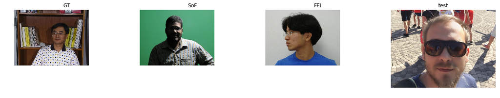

```python
images_to_show = [('GT', random_image_from(gt_with)),
                  ('SoF', random_image_from(sof_with)),
                  ('FEI', random_image_from(fei_with)),
                  ('test', random_image_from(test_with))]
show_titled(images_to_show)
```

# 2. Архитектуры решения

Для классификации изображений можно использовать различные методы машинного обучения, такие как KNN, SVM и пр., а также нейронные сети, сверточные нейронные сети. В контексте задачи детектирования очков, возникает ряд вопросов и проблем:

```
- если учить модель по целым изображениям двух классов, как потом она будет отрабатывать на множестве людей
- также при полных изображениях возникает вопрос сжатия (640 х 480 пикселей это много вычислений)
- если сначала находить лица на фото, часть лиц (с плохим освещением, поворотом) может отсекаться модель face detection, хотя модель по полному фото возможно детектировала бы там очки
- какую модель с наибольшей точностью выбрать, учитывая ограничения на вычисление
```

Рассмотрим следующее решение:

```
1. Face Detection на базе opencv - поиск всех лиц на фото
2. Поворот, усреднение лиц
3. Обрезание области глаз
4. Сжатие области с глазами
5. Классификация наличия очков в области или их отсуствие (tensorflow или sklearn модели)
```

Узнав точность и скорость данного решения, можно будет подумать над другими алгоритмами решения задачи

# 3. Face Detection и выделение области глаз

С помощью библиотеки opencv можно выделить лица на фотографии, ниже демонстрация

## Face Detection

Попробуем выделить лица на данном кадре

[figure not shown]

```python
demo_img = 'hard_test/mib.jpg'
demo_data = cv2.imread(demo_img)
plt.imshow(cv2.cvtColor(demo_data, cv2.COLOR_BGR2RGB))
```

Для этого используются каскады Хаара для поиска лиц https://ru.wikipedia.org/wiki/%D0%9F%D1%80%D0%B8%D0%B7%D0%BD%D0%B0%D0%BA%D0%B8_%D0%A5%D0%B0%D0%B0%D1%80%D0%B0

```python
casc_path = 'cascades/haarcascade_frontalface_alt2.xml'
face_сascade = cv2.CascadeClassifier(casc_path)
```

Найдем координаты лиц на ч\б кадре

```python
gray = cv2.cvtColor(demo_data, cv2.COLOR_BGR2GRAY)
faces = face_сascade.detectMultiScale(gray)
```

Можно выделить лица

[figure not shown]

```python
for (x,y,w,h) in faces:
    cv2.rectangle(demo_data,(x,y),(x+w,y+h),(255,0,0),2)
plt.imshow(demo_data)
```

Видно, что из двух лиц такой каскад нашел только одно

Также в opencv есть каскад для выделения глаз, о его применимости можно подумать далее, так как сама его ошибка может говорить об очках

[figure not shown]

```python
eye_casc_path = 'cascades/haarcascade_eye_tree_eyeglasses.xml'
eye_сascade = cv2.CascadeClassifier(eye_casc_path)
eyes = eye_сascade.detectMultiScale(gray)
for (x,y,w,h) in eyes:
    cv2.rectangle(demo_data,(x,y),(x+w,y+h),(0,255,0), 2)
plt.imshow(demo_data)
```

По всему фото результат интересный, так как был найден глаз на лице, которое не было детектировано. Вероятно, закрытые темными очками глаза не дали модели возможности распознать глаз

Подготовим функцию, которая для датасета находит лица и сохраняет их в отдельных обрезанных файлах

```python
import shutil

# добавление колонки с полученными участками лиц, для каждой фотографии в ['photo_path']
def save_cropped_faces(dataset, path_to_save, name='face_cropped', cascade=face_сascade):
    if os.path.exists(path_to_save):
        shutil.rmtree(path_to_save)
        os.mkdir(path_to_save)
    else:
        os.mkdir(path_to_save)
    originals = dataset['photo_path'].values
    dataset[name] = list(map(lambda path: crop_and_save(path, path_to_save, cascade), originals))
    return dataset

# получение зон и сохранения их
def crop_and_save(original_photo_path, cropped_path, cascade, min_max=(0, 2)):
    img = cv2.imread(original_photo_path)
    gray = cv2.cvtColor(img, cv2.COLOR_BGR2GRAY)
    sectors = face_сascade.detectMultiScale(gray)
    cropped_paths = []
    if len(sectors) > min_max[0] and len(sectors) < min_max[1]:
        num = 1
        original_name = original_photo_path.split('/')[-1].split('.')[0]

        for x, y, w, h in sectors:
            full_cropped_path = cropped_path + '/' + original_name + '_cropped_' + str(num) + '.jpg'
            cropped = img[y:y+h, x:x+w]
            cv2.imwrite(full_cropped_path, cropped)
            cropped_paths.append(full_cropped_path)
            num = num + 1
        return cropped_paths
    else:
        return None
```

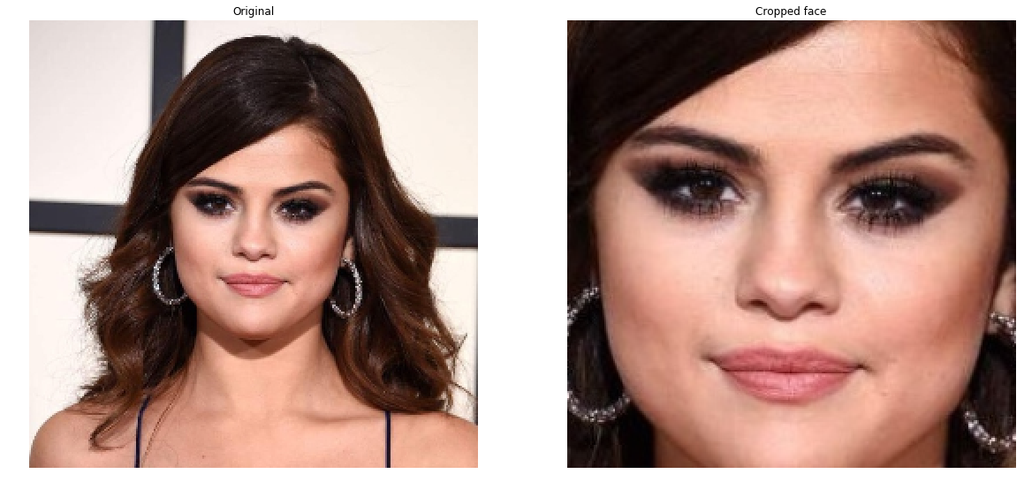

```python
# test
save_cropped_faces(test_without, 'test/face_cropped_without_glasses').head()
demo_original = test_without['photo_path'].values[0]
demo_cropped = test_without['face_cropped'].values[0][0]
to_show = [('Original', demo_original), ('Cropped face', demo_cropped)]
show_titled(to_show, resize=(256, 256))
```

Посмотрим на точность детектирования на больших датасетах

```python
%%time
save_cropped_faces(sof_with, 'sof/face_cropped_with_glasses').sample(5)
```

```
Wall time: 5min 20s
```

|  | dataset | photo_path | class | face_cropped |
| --- | --- | --- | --- | --- |
| 1360 | sof | sof/with_glasses/MeiH_01361_f_20_i_fr_nc_hp_20... | 1 | [sof/face_cropped_with_glasses/MeiH_01361_f_20... |
| 2505 | sof | sof/with_glasses/YosB_02506_f_20_i_fr_nc_no_20... | 1 | None |
| 1776 | sof | sof/with_glasses/MohG_01777_m_32_i_fr_nc_no_20... | 1 | None |
| 566 | sof | sof/with_glasses/AsmH_00567_f_28_i_nf_cr_sr_20... | 1 | [sof/face_cropped_with_glasses/AsmH_00567_f_28... |
| 2472 | sof | sof/with_glasses/YosB_02473_f_20_i_fr_nc_hp_20... | 1 | [sof/face_cropped_with_glasses/YosB_02473_f_20... |

```python
print('Face Detection percent in sof data: ', sof_with.count()[2]/sof_with.count()[0])
```

[output not shown]

## Найдем область глаз и очков

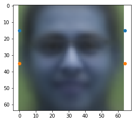

```python
def show_medium(photo_paths):
    size = 64
    sum_image = np.zeros((len(photo_paths), size*size*3))
    for i in range(len(photo_paths)):
        photo = photo_paths[i]
        img = cv2.imread(photo)
        resized = cv2.resize(img, (size, size))
        sum_image[i] = resized.flatten()

    sum_image = np.array(sum_image.mean(axis=0), dtype='int32').reshape(size, size, 3)
    plt.imshow(sum_image)
    plt.scatter(x=[0, 64], y=[15, 15])
    plt.scatter(x=[0, 64], y=[35, 35])

cropped_not_na = sof_with.dropna()['face_cropped'].values
show_medium([c[0] for c in cropped_not_na])
```

На изображение среднее всех найденных лиц в датасете sof. Точками отмечены примерные границы глаз, также слабо видна оправа очков, при общем размере 64 х 64 пикселей область глаз занимает область равную 20 х 64 пикселей. Однако и эту область, возможно, имеет смысл сократить, так можно брать лишь половину этой области (т.к очки и справа, и слева), также стоит подумать нужен ли модели цвет пикселей. Стоит посмотреть на точность при разных данных

Напишем функцию, которая сохраняет во фрейм только участок с глазами выбранного размера (данные и фото сохраняются)

```python
# добавление колонки с полученными участками лиц, для каждой фотографии в ['photo_path']
def save_cropped_eyes(dataset, path_to_save, name='eyes_cropped', cascade=face_сascade):
    if os.path.exists(path_to_save):
        shutil.rmtree(path_to_save)
        os.mkdir(path_to_save)
    else:
        os.mkdir(path_to_save)
    originals = dataset['photo_path'].values
    cropped_files_and_data = list(map(lambda path: crop_and_save(path, path_to_save, cascade), originals))
    dataset[name] = [d[0] for d in cropped_files_and_data]
    dataset[name + '_data'] = [d[1] for d in cropped_files_and_data]
    return dataset

# получение зоны глаз и добавление
def crop_and_save(original_photo_path, cropped_path, cascade, size=64, min_max=(0, 2)):
    img = cv2.imread(original_photo_path)
    gray = cv2.cvtColor(img, cv2.COLOR_BGR2GRAY)
    sectors = face_сascade.detectMultiScale(gray)
    cropped_paths = []
    cropped_data = []
    if len(sectors) > min_max[0] and len(sectors) < min_max[1]:
        num = 1
        original_name = original_photo_path.split('/')[-1].split('.')[0]

        for x, y, w, h in sectors:
            full_cropped_path = cropped_path + '/' + original_name + '_eyes_cropped_' + str(num) + '.jpg'
            face_cropped = gray[y:y+h, x:x+w]
            face_resized = cv2.resize(face_cropped, (size, size))
            eyes_img = get_eyes_from_face(face_resized, size)
            cv2.imwrite(full_cropped_path, eyes_img)
            cropped_paths.append(full_cropped_path)
            cropped_data.append(eyes_img)
            num = num + 1
        return cropped_paths, cropped_data
    else:
        return [None, None]

def get_eyes_from_face(face_img, size):
        y_top = int(15/64. * size)
        y_bottom = int(35/64. * size)
        eyes_img = face_img[y_top:y_bottom, ::]
        return eyes_img
```

Тест

```python
save_cropped_eyes(test_without, 'test/eyes_without_glasses').head()
demo_original = test_without['photo_path'].values[0]
demo_cropped = test_without['eyes_cropped'].values[0][0]
test_without.head()
```

|  | dataset | photo_path | class | face_cropped | eyes_cropped | eyes_cropped_data |
| --- | --- | --- | --- | --- | --- | --- |
| 0 | test | test/without_glasses/0.jpg | 0 | [test/face_cropped_without_glasses/0_cropped_1... | [test/eyes_without_glasses/0_eyes_cropped_1.jpg] | [[[9, 7, 9, 15, 25, 21, 13, 13, 14, 11, 37, 11... |
| 1 | test | test/without_glasses/1.jpg | 0 | [test/face_cropped_without_glasses/1_cropped_1... | [test/eyes_without_glasses/1_eyes_cropped_1.jpg] | [[[24, 17, 18, 11, 17, 50, 78, 92, 92, 95, 105... |
| 2 | test | test/without_glasses/10.jpg | 0 | [test/face_cropped_without_glasses/10_cropped_... | [test/eyes_without_glasses/10_eyes_cropped_1.jpg] | [[[72, 64, 60, 62, 58, 59, 62, 85, 90, 115, 13... |
| 3 | test | test/without_glasses/11.jpg | 0 | [test/face_cropped_without_glasses/11_cropped_... | [test/eyes_without_glasses/11_eyes_cropped_1.jpg] | [[[34, 33, 29, 29, 27, 31, 39, 57, 66, 43, 47,... |
| 4 | test | test/without_glasses/12.jpg | 0 | [test/face_cropped_without_glasses/12_cropped_... | [test/eyes_without_glasses/12_eyes_cropped_1.jpg] | [[[137, 139, 137, 114, 35, 53, 112, 125, 125, ... |

Оригинал

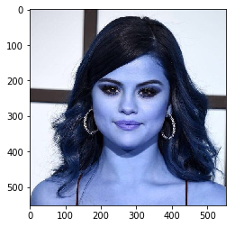

```python
original = cv2.imread(demo_original)
plt.imshow(original)
```

Глаза

```
Eyes shape:  (20, 64)
```

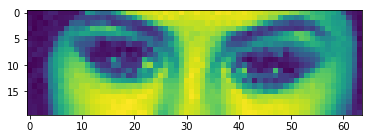

```python
eyes = cv2.imread(demo_cropped, cv2.COLOR_BGR2GRAY)
print('Eyes shape: ', eyes.shape)
plt.imshow(eyes)
```

## Данные для обучения и тестов

Для первых моделей объединим разобьем случайным образом все данные (кроме датасета для конечных тестов)

**Этот код можно пропустить, если фото глаз уже существуют в папках датасетов, для загрузки изображений глаз можно использовать блок кода ниже**

```python
save_cropped_eyes(sof_with, 'sof/eyes_with_glasses')
save_cropped_eyes(fei_with, 'fei/eyes_with_glasses')
save_cropped_eyes(fei_without, 'fei/eyes_without_glasses')
save_cropped_eyes(gt_with, 'GT/eyes_with_glasses')
save_cropped_eyes(gt_without, 'GT/eyes_without_glasses')
print('Saved')
```

```
Saved
```

**Загрузка изображения глаз из папок датасетов eyes_with_glasses, eyes_without_glasses**

```python
def load_cropped_eyes(dataset, cropped_path):
    cropped_paths = []
    cropped_data = []
    for original_photo_path in dataset['photo_path']:
        num = 1 # was 1 or 0 eyes image
        original_name = original_photo_path.split('/')[-1].split('.')[0]
        full_cropped_path = cropped_path + '/' + original_name + '_eyes_cropped_' + str(num) + '.jpg'
        if os.path.exists(full_cropped_path):
            cropped_paths.append([full_cropped_path])
            data = cv2.imread(full_cropped_path,  cv2.COLOR_BGR2GRAY)
            cropped_data.append([data])
        else:
            cropped_paths.append(None)
            cropped_data.append(None)
    dataset['eyes_cropped'] = cropped_paths
    dataset['eyes_cropped' + '_data'] = cropped_data

load_cropped_eyes(sof_with, 'sof/eyes_with_glasses')
load_cropped_eyes(fei_with, 'fei/eyes_with_glasses')
load_cropped_eyes(fei_without, 'fei/eyes_without_glasses')
load_cropped_eyes(gt_with, 'GT/eyes_with_glasses')
load_cropped_eyes(gt_without, 'GT/eyes_without_glasses')
```

```python
datasets = [sof_with, fei_with, fei_without, gt_with, gt_without]
full_frame = pd.concat(datasets, names=['dataset', 'photo_path', 'class', 'eyes_cropped', 'eyes_cropped_data'], ignore_index=True, sort=False)
```

```python
# Очистка пропусков и лишних столбцов
full_frame = full_frame.drop('face_cropped', axis=1)
frame = full_frame.dropna()
```

```python
frame.sample(5)
```

|  | dataset | photo_path | class | eyes_cropped | eyes_cropped_data |
| --- | --- | --- | --- | --- | --- |
| 3506 | fei | fei/without_glasses/146-05.jpg | 0 | [fei/eyes_without_glasses/146-05_eyes_cropped_... | [[[25, 20, 24, 28, 35, 29, 24, 29, 56, 95, 110... |
| 4566 | fei | fei/without_glasses/36-13.jpg | 0 | [fei/eyes_without_glasses/36-13_eyes_cropped_1... | [[[43, 39, 30, 32, 32, 46, 63, 75, 102, 115, 1... |
| 3406 | fei | fei/without_glasses/14-03.jpg | 0 | [fei/eyes_without_glasses/14-03_eyes_cropped_1... | [[[195, 195, 193, 196, 192, 196, 194, 193, 194... |
| 2201 | sof | sof/with_glasses/OliA_02202_f_20_i_fr_nc_sd_20... | 1 | [sof/eyes_with_glasses/OliA_02202_f_20_i_fr_nc... | [[[3, 2, 2, 2, 3, 4, 6, 8, 11, 15, 18, 19, 19,... |
| 3704 | fei | fei/without_glasses/159-07.jpg | 0 | [fei/eyes_without_glasses/159-07_eyes_cropped_... | [[[19, 25, 26, 41, 75, 105, 117, 118, 120, 128... |

```python
frame.groupby(by=['class']).count()
```

| class | dataset | photo_path | eyes_cropped | eyes_cropped_data |
| --- | --- | --- | --- | --- |
| 0 | 2762 | 2762 | 2762 | 2762 |
| 1 | 2103 | 2103 | 2103 | 2103 |

Для создания модели, необходимо разбить данные на данные для обучения и теста (обычно 25, 33 % ) либо использовать кросс-валидацию модели. Видно, что эксезмпляров классов больше 2000, пока не будем использовать кросс-валидацию, а будем проверять модели машинного обучения на отложенных даннных.

Таким образом данные должны быть представлены в виде пикселей объектов (X = [x0, x1 ... xn]) и соотвествующих меток класса - т.е. целовой переменной, человек в очках или нет y = [y0, y1 ... yn]

```python
# так как сейчас одно фото в данных
X = np.array([data[0] for data in frame['eyes_cropped_data'].values])/255.
print('X.shape = ', X.shape)
y = frame['class'].values
y = y.reshape(y.shape[0], 1)
print('y.shape = ', y.shape)
```

```
X.shape =  (4865, 20, 64)
y.shape =  (4865, 1)
```

```python
print('Example of X: ', X[0])
```

```
Example of X:  [[0.18823529 0.19607843 0.15294118 ... 0.68627451 0.76078431 0.78039216]
 [0.21176471 0.18039216 0.12941176 ... 0.53333333 0.78039216 0.78431373]
 [0.17254902 0.16078431 0.13333333 ... 0.55294118 0.71764706 0.78431373]
 ...
 [0.76470588 0.54509804 0.50588235 ... 0.75686275 0.78823529 0.78039216]
 [0.78823529 0.54901961 0.49019608 ... 0.77254902 0.78823529 0.79215686]
 [0.78431373 0.59215686 0.52156863 ... 0.77254902 0.78823529 0.78823529]]
```

С помощью библиотеки sklearn разобьем данные на обучение и тест, а также протестируем точность простейших моделей

```python
from sklearn.model_selection import train_test_split
train_images, test_images, X_train, X_test, y_train, y_test = train_test_split(frame['eyes_cropped'].values, X, y, random_state=13, test_size=0.3)
```

```python
print("X_test.shape= ", X_test.shape)
print("X_train.shape= ", X_train.shape)
```

```
X_test.shape=  (1460, 20, 64)
X_train.shape=  (3405, 20, 64)
```

# 4. Модели

Будем рассматривать разные модели, а также записывать лучшие результаты в сводную такблицу, где будут следующие метрики: время выполнение одной классификации, accuracy, recall, precision, f1_score, время обучения.

## Random Forest

Попробуем какую-то простейшую модель вроде случайного леса, чтобы оценить сложность обучения

```python
from sklearn.ensemble import RandomForestClassifier
```

Функция подсчета времени

```python
import time
def time_one(func):
    start = time.time()
    result = func(None)
    end = time.time()
    return 1000 * (end - start)

def time_it(func, divider=1, times_to_run=1):
    times = list(map(time_one, [func]*times_to_run))
    mean_time = np.array(times).mean()/divider
    return mean_time
```

```python
from sklearn.metrics import classification_report
from sklearn.metrics import accuracy_score
```

```python
%%time
size = 100
demo_X_train = np.array([x.flatten() for x in X_train[:size]])
print('Demo shape: ', demo_X_train.shape)
demo_y_train = y_train[:size].reshape((size, ))

flat_X_test = np.array([x.flatten() for x in X_test])

forest = RandomForestClassifier(n_estimators=100)

mean_learn_time = time_it(lambda x: forest.fit(demo_X_train, demo_y_train), times_to_run=1, divider=size)
mean_pred_time = time_it(lambda x: forest.predict(flat_X_test), times_to_run=1, divider=size)
predicted = forest.predict(flat_X_test)

print('Время обучения: %f ms' % mean_learn_time)
print('Время классификации одного объекта: %f ms' % mean_pred_time)
print('Accuracy : %f' % accuracy_score(predicted, y_test) )
print(classification_report(predicted, y_test))
```

```
Demo shape:  (100, 1280)
Время обучения: 18.661065 ms
Время классификации одного объекта: 2.200127 ms
Accuracy : 0.891096
             precision    recall  f1-score   support

          0       0.91      0.90      0.90       841
          1       0.86      0.88      0.87       619

avg / total       0.89      0.89      0.89      1460

Wall time: 2.59 s
```

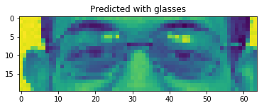

```python
def show_rand_pred(predicted, test_images):
    i = random.randint(0, len(X_test))
    name = test_images[i][0]
    prediction = predicted[i]
    pred_data = cv2.imread(name, cv2.COLOR_BGR2GRAY)
    plt.imshow(pred_data)
    plt.title('Predicted with glasses' if prediction==1 else 'Predicted without glasses')
show_rand_pred(predicted, test_images)
```

Вероятно, что для алгоритмов это не cложная классификация и можно добиться весьма хорошей точности (98-99%). Посмотрим как меняется точность от количества данных для обучения.

```
Результаты:  [0.8883561643835617, 0.8842465753424658, 0.8993150684931507, 0.915068493150685, 0.9267123287671233, 0.934931506849315, 0.947945205479452, 0.9527397260273973, 0.9554794520547946]
Wall time: 1min 8s
```

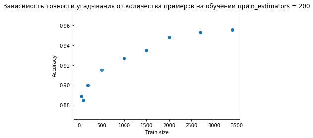

```python
%%time
sizes = [50, 100, 200, 500, 1000, 1500, 2000, 2700, len(X_train)]
clfs = []

def get_one_size_result(size, clf=RandomForestClassifier(n_estimators=200)):
    demo_X_train = np.array([x.flatten() for x in X_train[:size]])
    demo_y_train = y_train[:size].reshape((size, ))
    flat_X_test = np.array([x.flatten() for x in X_test])
    clf.fit(demo_X_train, demo_y_train)
    clfs.append(clf)
    predicted = clf.predict(flat_X_test)
    acc = accuracy_score(predicted, y_test)
    return acc

result_for_sizes = list(map(lambda size: get_one_size_result(size), sizes))
print('Результаты: ', result_for_sizes)
plt.scatter(x=sizes, y=result_for_sizes)
plt.title('Зависимость точности угадывания от количества примеров на обучении при n_estimators = 200')
plt.xlabel('Train size')
plt.ylabel('Accuracy')
```

## Сохранение и загрузка моделей sklearn

Для сохранения и загрузки моделей используется модуль pickle, напишем соответсвующие функцию и функцию измерения веса модели

```python
import pickle

def get_full_path(file_name, file ='.pkl'):
    folder = 'models/'
    full_path = folder + file_name + file
    return full_path

def save_sklearn_estimator(estimator, file_name):
    f = get_full_path(file_name)
    with open(f, 'wb') as file:
        pickle.dump(estimator, file)
    return f

def load_sklearn_estimator(file_name):
    f = get_full_path(file_name)
    with open(f, 'rb') as file:
        estimator = pickle.load(file)
    return estimator

def sklearn_estimator_weight(file_name):
    f = get_full_path(file_name)
    return os.path.getsize(f)/(2**20)
```

```python
# test
last_forest = clfs[-1]
save_sklearn_estimator(last_forest, 'forest')
loaded_forest = load_sklearn_estimator('forest')
print('Loaded forest score: ', loaded_forest.score(flat_X_test, y_test))
print('Saved model weight is %f MB' % sklearn_estimator_weight('forest'))
```

```
Loaded forest score:  0.9554794520547946
Saved model weight is 3.946948 MB
```

Видно, что модель с n_estimators весит более 3 мегабайт, нужно взять меньшее число решающих деревьев

```python
light_forest = RandomForestClassifier(n_estimators=150)
flat_X_train = np.array([x.flatten() for x in X_train])
flat_y_train = y_train.reshape((len(y_train), ))
mean_learn_time = time_it(lambda x: light_forest.fit(flat_X_train, flat_y_train), times_to_run=1, divider=len(flat_X_test))
mean_pred_time = time_it(lambda x: light_forest.predict(flat_X_test), times_to_run=1, divider=len(flat_X_test))
predicted = light_forest.predict(flat_X_test)

print('Время обучения: %f ms' % mean_learn_time)
print('Время классификации одного объекта: %f ms' % mean_pred_time)
print('Accuracy : %f' % accuracy_score(predicted, y_test) )
print(classification_report(predicted, y_test))
```

```
Время обучения: 10.293054 ms
Время классификации одного объекта: 0.060962 ms
Accuracy : 0.956164
             precision    recall  f1-score   support

          0       0.97      0.95      0.96       848
          1       0.93      0.97      0.95       612

avg / total       0.96      0.96      0.96      1460
```

Сохраним и взвесим данную модель и рассмотрим другие методы машинного обучения

```python
# light
save_sklearn_estimator(light_forest, 'forest')
print('Saved model weight is %f MB' % sklearn_estimator_weight('forest'))
```

```
Saved model weight is 2.992268 MB
```

## PCA

Поиск оптимального алгоритма затрачивает много вычислительных ресурсов. Посмотрим можно ли сжать наше изображение не сильно потеряв в качестве.

```python
from sklearn.decomposition import PCA
```

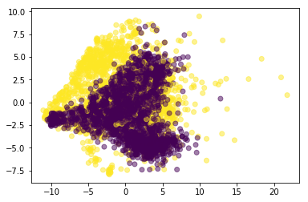

```python
flat_X = np.array([x.flatten() for x in X])
pca = PCA(n_components=2)
compressed_X = pca.fit_transform(flat_X)
plt.scatter(x=[c[0] for c in compressed_X], y=[c[1] for c in compressed_X], alpha=0.5, c=y.flatten())
```

На рисунке, информация изображений сжатая до 2 признаков, цвета показывают два разных класса: с очками и без. Можно заметить, что часть объектов различимы даже при 2 признаках

```
Wall time: 29.4 s
```

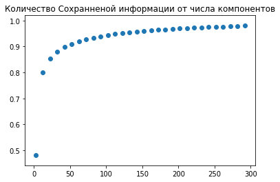

```python
%%time
check_sizes = list(range(2, 300, 10))
informations = list(map(lambda size: sum(PCA(n_components=size).fit(flat_X).explained_variance_ratio_), check_sizes))
plt.scatter(check_sizes, informations)
plt.title('Количество Сохранненой информации от числа компонентов')
```

```python
# Сохраним 95% информации
pca = PCA(n_components = 0.95)
compressed_X = pca.fit_transform(flat_X)
print('Сократили до %d признаков' % pca.n_components_)
```

```
Сократили до 118 признаков
```

```python
# Измерим время одного вычисления и сохраним PCA модель
mean_pred_time = time_it(lambda x: pca.transform(flat_X_train), times_to_run=1, divider=len(flat_X_train))
print('Время на сжатие одного объекта: %f ms ' % mean_pred_time)

save_sklearn_estimator(pca, 'pca')
print('Saved model weight is %f MB' % sklearn_estimator_weight('pca'))
```

```
Время на сжатие одного объекта: 0.040237 ms
Saved model weight is 1.165623 MB
```

```python
compressed_X_train = pca.transform(flat_X_train)
compressed_X_test = pca.transform(flat_X_test)
```

## SVC

После сокращения пространства признаков можно проверить качество моделей SVC

```python
from sklearn.svm import SVC
svc = SVC(kernel='rbf', degree=2, C=100)

mean_learn_time = time_it(lambda x: svc.fit(compressed_X_train, flat_y_train), times_to_run=1, divider=len(flat_X_test))
mean_pred_time = time_it(lambda x: svc.predict(compressed_X_test), times_to_run=1, divider=len(flat_X_test))
predicted = svc.predict(compressed_X_test)

print('Время обучения: %f ms' % mean_learn_time)
print('Время классификации одного объекта: %f ms' % mean_pred_time)
print('Accuracy : %f' % accuracy_score(predicted, y_test) )
print(classification_report(predicted, y_test))
```

```
Время обучения: 1.305554 ms
Время классификации одного объекта: 0.230150 ms
Accuracy : 0.958219
             precision    recall  f1-score   support

          0       0.97      0.95      0.96       841
          1       0.94      0.96      0.95       619

avg / total       0.96      0.96      0.96      1460
```

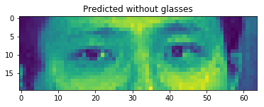

```python
show_rand_pred(predicted, test_images)
```

```python
# svc
save_sklearn_estimator(svc, 'svc')
print('Saved SVC model weight is %f MB' % sklearn_estimator_weight('svc'))
```

```
Saved SVC model weight is 0.579567 MB
```

Ошибка в несколько процентов неплохой результат для простых моделей. Дальнейшее улучшение потребует перебора по сетке (GridSearch) для поиска наилучших параметров. Также может потребоваться изучение данных, где были наибольшие ошибки или увеличение самого количества данных для обучения

## CNN

Может оказаться, что для SVC и Random Forest классификаторов существует предел точности, поэтому стоить посмотреть на более сложные модели, например, на качество сверточной нейронной сети (CNN) из модуля Keras на базе tensorflow

```python
from keras.models import Sequential
from keras.layers import Dense
from keras.layers import Conv2D
from keras.layers import MaxPooling2D
from keras.layers import Flatten
from keras.optimizers import SGD
```

Подготовим данные в специальный вид

```python
keras_y_train = np.array([[0, 1] if y==1 else [1, 0] for y in y_train])
keras_y_test = np.array([[0, 1] if y==1 else [1, 0] for y in y_test])
keras_X_train = X_train.reshape(X_train.shape[0], X_train.shape[1], X_train.shape[2], 1)
keras_X_test = X_test.reshape(X_test.shape[0], X_test.shape[1], X_test.shape[2], 1)
print('keras x train shape = ', keras_X_train.shape)
print('keras y train shape = ', keras_y_train.shape)
```

```
keras x train shape =  (3405, 20, 64, 1)
keras y train shape =  (3405, 2)
```

Ниже код для построения модели сверточной нейронной сети, параметры ядра свертки, скорости градиентного спуска и количества нейронов, подобраны после нескольких экспериментов

```python
# Initialising the CNN
classifier = Sequential()

# Step 1 - Convolution
classifier.add(Conv2D(32, (2, 4), input_shape=(keras_X_train[0].shape), data_format='channels_last', activation = 'tanh'))
classifier.add(MaxPooling2D(pool_size=(2, 4)))

classifier.add(Flatten())
classifier.add(Dense(units = 128, activation = 'tanh'))
classifier.add(Dense(units = len(keras_y_train[0]), activation = 'softmax'))

# Compiling the CNN
classifier.compile(optimizer = SGD(lr=0.01),  loss = 'categorical_crossentropy', metrics = ['accuracy'])
```

```python
%%time
classifier.fit(keras_X_train, keras_y_train, epochs=150, batch_size=50)
```

```
Wall time: 11min 11s
```

```
<keras.callbacks.History at 0x287a95c0>
```

```python
%%time
mean_pred_time = time_it(lambda x: classifier.predict_classes(keras_X_test), times_to_run=1, divider=len(keras_X_test))
predicted = classifier.predict_classes(keras_X_test)

print('Время классификации одного объекта: %f ms' % mean_pred_time)
print('Accuracy : %f' % accuracy_score(predicted, y_test))
print(classification_report(predicted, y_test))
```

```
Время классификации одного объекта: 5.229066 ms
Accuracy : 0.980822
             precision    recall  f1-score   support

          0       1.00      0.97      0.98       846
          1       0.96      0.99      0.98       614

avg / total       0.98      0.98      0.98      1460

Wall time: 8.17 s
```

Теперь необходимы новые функции для сохранения\загрузки рабочей keras модели

```python
from keras.models import model_from_json
def save_keras_model(keras_model, file_name):
    model_json = keras_model.to_json()
    f = get_full_path(file_name, '.json')
    with open(f, "w") as json_file:
        json_file.write(model_json)

    f = get_full_path(file_name, '.h5')
    keras_model.save_weights(f)

def load_keras_model(file_name):
    f = get_full_path(file_name, '.json')
    json_file = open(f, 'r')
    json_model = json_file.read()
    json_file.close()
    loaded_model = model_from_json(json_model)
    weights_f = get_full_path(file_name, '.h5')
    loaded_model.load_weights(weights_f)
    return loaded_model

def keras_model_weight(file_name):
    f1 = get_full_path(file_name, '.json')
    f2 = get_full_path(file_name, '.h5')
    return (os.path.getsize(f1) + os.path.getsize(f2) )/(2**20)
```

```python
save_keras_model(classifier, 'cnn')
loaded_model = load_keras_model('cnn')
predicted = loaded_model.predict_classes(keras_X_test)
print('Loaded CNN score: ', accuracy_score(predicted, y_test))
print('Saved model weight is %f MB' % keras_model_weight('cnn'))
```

```
Loaded CNN score:  0.9808219178082191
Saved model weight is 2.129969 MB
```

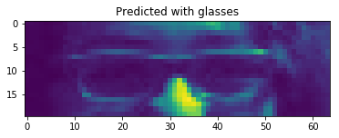

```python
show_rand_pred(predicted, test_images)
```

# 5. Использование

Чтобы быстро использовать модель (пока лучшую CNN) код был переписан в полный скрипт python. Весь проект доступен на github

Варианты запуска:

```
- python glasses_ai.py [Путь к папке с изображениями для поиска людей]
- python glasses_ai.py [Набор путей к фотографиям]
```

Результатом работы будет csv-file с найденным лицами и результатом классификации в очках или нет, вывод его на консоль, а также сохранение в новой папке в results, а также сохранения результатов работы по изображениям, с выделенными зонами в очках и без

Протестируем результат работы с папкой тест (фотографии из задания)

```python
%run -i glasses_ai.py test/with_glasses/
```

```
Analyse images from paths :  ['test/with_glasses/']
              original_image  predicted_class        eyes_position:
0    test/with_glasses/0.jpg              1.0  (167, 293, 377, 118)
1    test/with_glasses/0.jpg              1.0    (179, 622, 57, 18)
2    test/with_glasses/1.jpg              1.0  (252, 292, 423, 132)
3   test/with_glasses/10.jpg              1.0  (179, 290, 355, 111)
4   test/with_glasses/11.jpg              1.0  (172, 275, 534, 167)
5   test/with_glasses/11.jpg              0.0    (446, 427, 68, 22)
6   test/with_glasses/13.jpg              1.0  (253, 305, 378, 118)
7   test/with_glasses/14.jpg              1.0  (162, 318, 383, 120)
8   test/with_glasses/17.jpg              1.0  (156, 254, 401, 126)
9   test/with_glasses/18.jpg              1.0   (177, 228, 309, 96)
10  test/with_glasses/19.jpg              1.0  (134, 318, 392, 123)
11   test/with_glasses/2.jpg              1.0   (130, 160, 197, 61)
12   test/with_glasses/3.jpg              0.0   (107, 349, 288, 90)
13   test/with_glasses/4.jpg              1.0  (146, 329, 394, 123)
14   test/with_glasses/5.jpg              0.0   (284, 449, 105, 33)
15   test/with_glasses/6.jpg              1.0  (100, 317, 400, 125)
16   test/with_glasses/7.jpg              1.0  (103, 196, 503, 158)
17   test/with_glasses/8.jpg              1.0  (162, 263, 366, 115)
18   test/with_glasses/9.jpg              1.0  (153, 316, 383, 120)
End of recognition. Time: 8.616493 s
```

Видно, что нейронная сеть ошиблась 3 раза и часть лиц не была найдена средствами opencv. Результаты в папке results.

# 6. Выводы

В ходе выполнения задания были найдены и разбиты на данные для обучения и тестов изображения людей в очках и без очков. Простейшие модели хорошо показали себя на тестах. Однако в рельности нужно смотреть не переобучились ли они под специфику датасетов. Скорость моделей - миллисекунды (на CPU - Intel Core i5) - на мобильных устройствах скорость, вероятно не будет превышать 100мс на объект. Все модели весят меньше 3 Мбайт. Основная проблема - плохое детектирование лиц. Лучше всего себя показала сверточная нейронная сеть, которая используется в коде скрипта. Дальнейшая разработка под мобильные устройства возможна, но необходимо использовать специальные фреймворки для перевода модели под платформы смартфонов: sklearn-porter, tensorflow для мобильных устройств.

*Соколов Олег*sokolegg@yandex.ru